# Задание 5. Анализ корзины покупателя

Дмитрий Бодунов

29 октября 2016 г

Задача - определить группы товаров, которые наиболее часто покупаются вместе. Показать силу связи. Вывести наиболее интересные и неожиданные на ваш взгляд соответствия.

Поиск групп товаров - анализ корзины покупателя, осуществляется с помощью анализа совместных покупок. С помощью данного метода могут быть получены ассоциативные правила, которые свидетельствуют о наличии связи между товарами.

Предварительный анализ транзакционных данных показал, что в покупках есть большое количество пакетов и купонов, которые могут исказить реультаты. Перед основным анализом исключим пакеты и купоны из транзакционных данных TXN.

Выведем график 30 самых популярных товаров среди оставшихся:

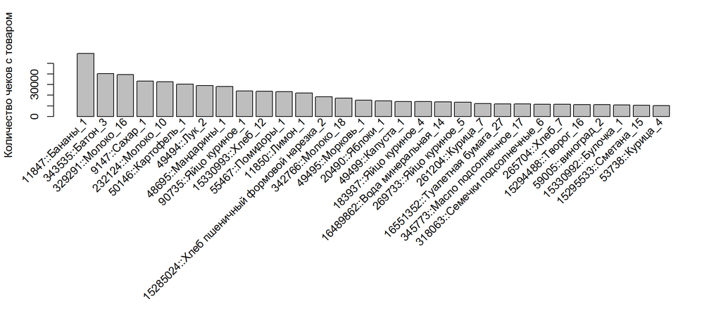

Самые популярные товары могут встречаться в большинстве ассоциативных правил (т.н. “банановая ловушка”). Данную проблему мы решим введением специальной вероятностной метрики. Основные метрики support(A, B) - вероятность встретить оба товара в чеке и confidence(A, B) - вероятность встретить товар B в чеке с товаром A. Confidence можно рассматривать как силу связи между товарами. Так же подобной метрикой может выступать lift - отношение support(A, B) к (support(A) * support(B)).

Рассчитаем ассоциативные правила с support >= 0.0001 (около 90 чеков), confidence >= 0.15. Уберем банановую ловушку с помощью собственной метрики. Отсортируем список по убыванию confidence и выведем первые 50 элементов списка.

| LHS | RHS | support | confidence | lift | ownMetric |
| --- | --- | --- | --- | --- | --- |
| {342002::Каша_3} | {342003::Каша_4} | 0.0007 | 0.5101 | 238.9351 | 486.6633 |
| {364162::Влажный корм для кошек_31} | {325606::Влажный корм для кошек_22} | 0.0012 | 0.4909 | 192.4796 | 377.0968 |
| {16377008::Влажный корм для кошек_45} | {16378491::Влажный корм для кошек_47} | 0.0009 | 0.4742 | 237.7248 | 451.2462 |
| {247133::Каша_14} | {243249::Каша_12} | 0.0004 | 0.4742 | 536.3583 | 1019.1490 |
| {16378491::Влажный корм для кошек_47} | {16377008::Влажный корм для кошек_45} | 0.0009 | 0.4704 | 237.7248 | 447.9578 |
| {325606::Влажный корм для кошек_22} | {364162::Влажный корм для кошек_31} | 0.0012 | 0.4692 | 192.4796 | 361.7120 |
| {14289::Петрушка_1} | {11345::Зелень_1} | 0.0018 | 0.4677 | 58.4441 | 108.9141 |
| {331303::Разрыхлитель_1} | {313491::Ванилин_1} | 0.0010 | 0.4649 | 105.2984 | 195.9106 |
| {16515878::Влажный корм для кошек_52} | {16515880::Влажный корм для кошек_53} | 0.0015 | 0.4634 | 140.4688 | 260.8993 |
| {325605::Влажный корм для кошек_21} | {325606::Влажный корм для кошек_22} | 0.0009 | 0.4600 | 180.3638 | 333.1418 |
| {16515880::Влажный корм для кошек_53} | {16515878::Влажный корм для кошек_52} | 0.0015 | 0.4535 | 140.4688 | 256.1893 |
| {355323::Влажный корм для собак_4} | {136468::Влажный корм для собак_1} | 0.0002 | 0.4483 | 400.4337 | 724.9736 |
| {136324::Влажный корм для кошек_13} | {60447::Влажный корм для кошек_6} | 0.0008 | 0.4481 | 176.4620 | 318.9312 |
| {16527090::Влажный корм для кошек_54} | {16377008::Влажный корм для кошек_45} | 0.0004 | 0.4472 | 226.0415 | 408.1291 |
| {325605::Влажный корм для кошек_21} | {364162::Влажный корм для кошек_31} | 0.0009 | 0.4441 | 182.1890 | 326.9257 |
| {94106::Влажный корм для кошек_8} | {94108::Влажный корм для кошек_10} | 0.0001 | 0.4353 | 1003.1031 | 1775.4245 |
| {243249::Каша_12} | {247133::Каша_14} | 0.0004 | 0.4282 | 536.3583 | 937.3025 |
| {16541562::Йогурты пастеризованные_1} | {16541548::Йогурт_16} | 0.0002 | 0.4269 | 309.5982 | 539.4284 |
| {16376815::Влажный корм для кошек_42} | {16377008::Влажный корм для кошек_45} | 0.0007 | 0.4177 | 211.1104 | 361.8316 |
| {16376815::Влажный корм для кошек_42} | {16378491::Влажный корм для кошек_47} | 0.0007 | 0.4177 | 209.3885 | 358.8744 |
| {55468::Огурцы_2} | {55467::Помидоры_1} | 0.0045 | 0.4173 | 16.4767 | 27.5623 |
| {45813::Влажный корм для кошек_4} | {60447::Влажный корм для кошек_6} | 0.0010 | 0.4147 | 163.3050 | 278.3031 |
| {16381821::Развесные конфеты_1} | {16383025::Конфеты_131} | 0.0004 | 0.4117 | 258.7114 | 439.0610 |
| {320717::Набор одноразовых тарелок_1} | {320718::Набор одноразовых стаканов_1} | 0.0006 | 0.4116 | 133.6176 | 226.4019 |
| {320717::Набор одноразовых тарелок_1} | {320719::Набор одноразовых вилок_1} | 0.0006 | 0.4074 | 221.5625 | 373.1826 |
| {56188::Огурцы_3} | {55467::Помидоры_1} | 0.0012 | 0.4057 | 16.0190 | 26.2738 |
| {227242::Сырок_4} | {226031::Сырок_3} | 0.0004 | 0.4026 | 81.1260 | 135.1271 |
| {45651::Влажный корм для кошек_3} | {60447::Влажный корм для кошек_6} | 0.0010 | 0.4018 | 158.2372 | 263.8648 |
| {60447::Влажный корм для кошек_6} | {45651::Влажный корм для кошек_3} | 0.0010 | 0.3934 | 158.2372 | 260.2199 |
| {136324::Влажный корм для кошек_13} | {45651::Влажный корм для кошек_3} | 0.0007 | 0.3903 | 156.9938 | 256.8660 |
| {254658::Желе_1} | {259492::Желе_2} | 0.0002 | 0.3890 | 437.3150 | 715.0932 |
| {60447::Влажный корм для кошек_6} | {45813::Влажный корм для кошек_4} | 0.0010 | 0.3832 | 163.3050 | 264.1274 |
| {16349417::Огурцы_5} | {55467::Помидоры_1} | 0.0010 | 0.3791 | 14.9676 | 23.4965 |
| {45813::Влажный корм для кошек_4} | {45651::Влажный корм для кошек_3} | 0.0009 | 0.3754 | 150.9906 | 241.1404 |
| {48507::Огурцы_1} | {55467::Помидоры_1} | 0.0038 | 0.3750 | 14.8050 | 23.0881 |
| {15305372::Сырок_18} | {329836::Сырок_8} | 0.0003 | 0.3729 | 95.9644 | 152.4297 |
| {16527090::Влажный корм для кошек_54} | {16378491::Влажный корм для кошек_47} | 0.0004 | 0.3716 | 186.2566 | 295.7879 |
| {94108::Влажный корм для кошек_10} | {363770::Влажный корм для кошек_30} | 0.0002 | 0.3675 | 697.0855 | 1101.5304 |
| {364162::Влажный корм для кошек_31} | {325605::Влажный корм для кошек_21} | 0.0009 | 0.3605 | 182.1890 | 284.3205 |
| {94107::Влажный корм для кошек_9} | {363770::Влажный корм для кошек_30} | 0.0002 | 0.3592 | 681.4247 | 1062.9087 |
| {325606::Влажный корм для кошек_22} | {325605::Влажный корм для кошек_21} | 0.0009 | 0.3569 | 180.3638 | 279.8918 |
| {94106::Влажный корм для кошек_8} | {94107::Влажный корм для кошек_9} | 0.0001 | 0.3561 | 689.6812 | 1070.5720 |
| {16358761::Каша_5} | {342002::Каша_3} | 0.0001 | 0.3550 | 244.4269 | 378.4233 |
| {16358761::Каша_5} | {342003::Каша_4} | 0.0001 | 0.3550 | 166.3047 | 257.2981 |
| {98486::Творожные изделия_2} | {98485::Творожные изделия_1} | 0.0004 | 0.3544 | 241.6680 | 373.7995 |
| {45651::Влажный корм для кошек_3} | {45813::Влажный корм для кошек_4} | 0.0009 | 0.3543 | 150.9906 | 233.2827 |
| {262322::Астрология и изотерика_3} | {205869::Интервью, истории, события_5} | 0.0002 | 0.3539 | 392.6161 | 607.1411 |
| {153521::Суп моментального приготовления_3} | {123106::Суп моментального приготовления_2} | 0.0002 | 0.3529 | 437.3150 | 675.3050 |
| {16413508::Йогурт_62} | {16413430::Йогурт_58} | 0.0002 | 0.3522 | 496.4530 | 765.8255 |
| {363770::Влажный корм для кошек_30} | {94107::Влажный корм для кошек_9} | 0.0002 | 0.3519 | 681.4247 | 1050.7981 |

Данные правила уже можно использовать совместно с коллегами для составления новых акций, использовать в ценообразовании или в управлении ассортиментом. Несколько интересных правил из найденных:

{262322::Астрология и изотерика_3} —–> {205869::Интервью, истории, события_5}  
{331303::Разрыхлитель_1} —–> {313491::Ванилин_1}  
{320717::Набор одноразовых тарелок_1} —–> {320718::Набор одноразовых стаканов_1}  
{320717::Набор одноразовых тарелок_1} —–> {320719::Набор одноразовых вилок_1}

Однако большинство правил не выглядят необычными. Скорее всего это товары одного производителя, но с разными вкусами. С помощью них можно строить аналоговые группы или самостоятельные иерархии справочника, например для прогнозирования оборота.

Для более удобного поиска новых и неочевидных правил необходима информация о брендах, полное название, харакетристики (например масса, объем, производитель, калорийность, сила бренда и пр.). Хотя можно также использовать информацию о группах. Посмотрим на правила, в кототрых товары принадлежат разным категориям, выставим значение собственной метрики >= 20 и выведем первые 10 товаров.

| LHS | RHS | support | confidence | lift | ownMetric |
| --- | --- | --- | --- | --- | --- |
| {55468::Огурцы_2} | {55467::Помидоры_1} | 0.0045 | 0.4173 | 16.4767 | 27.5623 |
| {56188::Огурцы_3} | {55467::Помидоры_1} | 0.0012 | 0.4057 | 16.0190 | 26.2738 |
| {16349417::Огурцы_5} | {55467::Помидоры_1} | 0.0010 | 0.3791 | 14.9676 | 23.4965 |
| {48507::Огурцы_1} | {55467::Помидоры_1} | 0.0038 | 0.3750 | 14.8050 | 23.0881 |
| {192542::Смесь_3} | {53736::Курица_2} | 0.0004 | 0.3351 | 42.8783 | 63.9824 |
| {15536020::Смесь для вторых блюд_1} | {53738::Курица_4} | 0.0002 | 0.2559 | 23.0610 | 30.6483 |
| {336227::Сухая смесь_1} | {261204::Курица_7} | 0.0001 | 0.2287 | 17.1848 | 21.9832 |
| {113245::Рис_6} | {111180::Крупа гречневая_3} | 0.0001 | 0.1800 | 118.4576 | 144.2455 |
| {59008::Баклажаны_1} | {59007::Перец_1} | 0.0004 | 0.1583 | 33.9270 | 40.1208 |
| {172635::Крупа пшеничная_2} | {111180::Крупа гречневая_3} | 0.0001 | 0.1566 | 103.0503 | 122.0003 |

Из списка можно выделить интересные правила:

{192542::Смесь_3} —–> {53736::Курица_2}  
{15536020::Смесь для вторых блюд_1} —–> {53738::Курица_4}  
{336227::Сухая смесь_1} —–> {261204::Курица_7}

Скорее всего это приправы для различных видов курицы (филе, ножки и пр.).

Для просмотра не только пар товаров но и понимания наборов товаров, которые часто берут вместе построим граф ассоциативных правил, который наглядно погажет, что часто берут люди в одном чеке (большая версия).

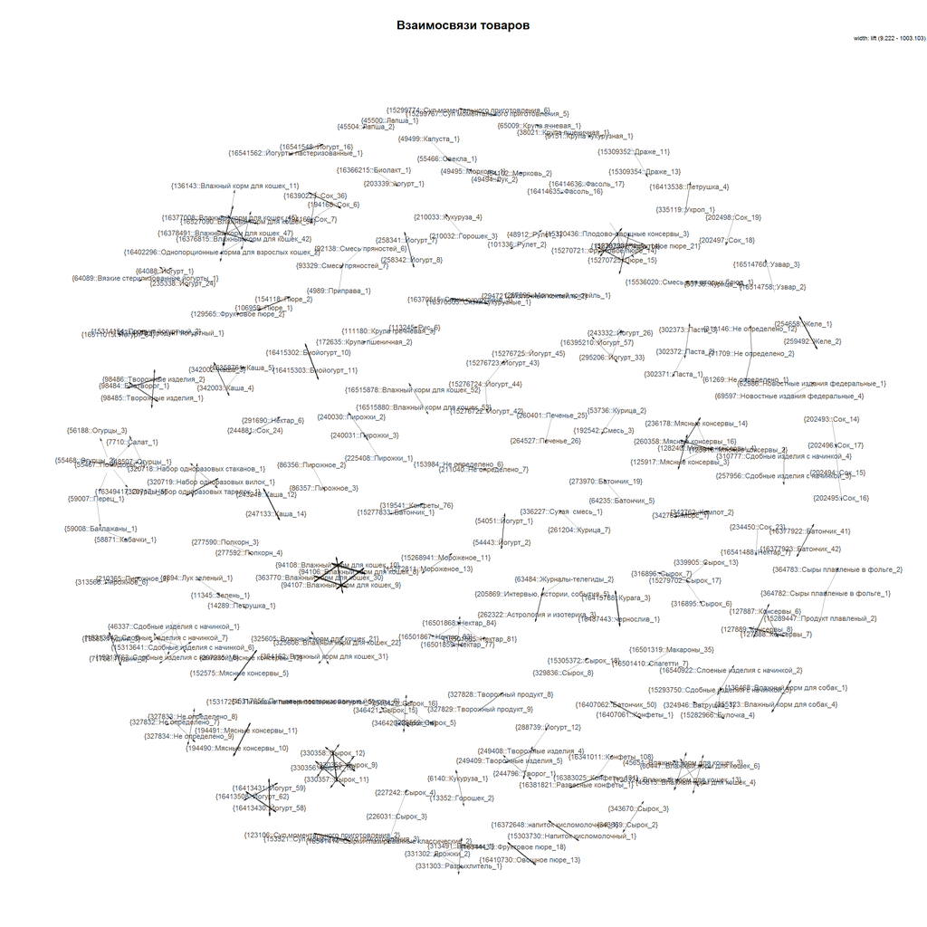

Из графа можно вынести еще одно интересное правило:

**{342769::Морс_1} —–> {342762::Компот_2}**

Т.к. подобный граф может очень большим, для того чтобы не анализировать граф взаимосвязей визуально кластеризуем его автоматически. Предварительно еще уменьшим пороги confidence и support для поиска более неочевидных групп.

В результате уменьшения порогов, получим следующим граф взаимодействий. Большую веерсию графа можно посмотреть здесь

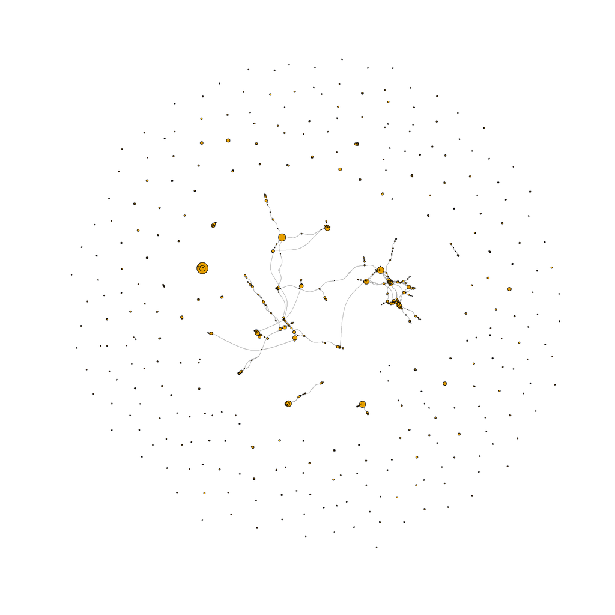

Выше приведен пример более полного графа ассоциативных правил. Он уже практически не поддается визуальному анализу. Кларизуем его и представим правила в виде списка. Большую веерсию графа можно посмотреть здесь

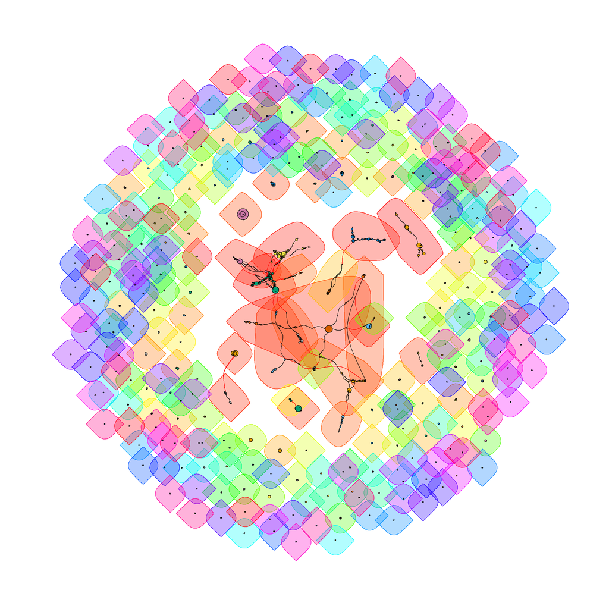

Выведем товары, например, из кластера номер 11. Все эти товары объединяет одно - это печатные издания. Полный список получившихся кластеров можно посмотреть в Excel файле

| Name | cluster |
| --- | --- |
| {63465::Журналы для женщин_3} | 11 |
| {69605::Газеты о здоровье_2} | 11 |
| {15317327::Кулинария_10} | 11 |
| {16411355::Желтая пресса_5} | 11 |
| {300584::Кулинария_9} | 11 |
| {16414413::Кулинария_13} | 11 |
| {16347482::Новостные издания местные_2} | 11 |
| {62995::Журналы для женщин_2} | 11 |
| {16409609::Садоводство, цветоводство_1} | 11 |
| {16400934::Журналы для женщин_11} | 11 |
| {15335650::Интервью, истории, события_7} | 11 |
| {16400935::Журналы для женщин_12} | 11 |
| {16502725::Интервью, истории, события_11} | 11 |
| {63478::Газета_1} | 11 |
| {322621::Познавательные издания_3} | 11 |
| {269798::Кулинария_5} | 11 |
| {201683::Кулинария_2} | 11 |
| {205220::Кулинария_3} | 11 |
| {154255::Кулинария_1} | 11 |
| {287340::Журналы о красоте_2} | 11 |
| {265073::Познавательные издания_2} | 11 |
| {16511296::Журналы для женщин_13} | 11 |
| {115302::Журналы для женщин_6} | 11 |
| {307595::Журналы для женщин_9} | 11 |
| {16405723::Интервью, истории, события_10} | 11 |
| {262322::Астрология и изотерика_3} | 11 |
| {62790::Кроссворды_2} | 11 |
| {68914::Желтая пресса_1} | 11 |
| {15317390::Кроссворды_17} | 11 |
| {329221::Журнал_3} | 11 |
| {265084::Кулинария_4} | 11 |
| {66224::Газеты о здоровье_1} | 11 |
| {66237::Кроссворды_4} | 11 |
| {15305753::Астрология и изотерика_7} | 11 |
| {364442::Журнал_18} | 11 |
| {205869::Интервью, истории, события_5} | 11 |
| {69589::Желтая пресса_2} | 11 |
| {330434::Газета_2} | 11 |
| {233730::Кроссворды_11} | 11 |
| {211713::Кроссворды_10} | 11 |
| {285416::Кулинария_7} | 11 |
| {128081::Журналы для женщин_7} | 11 |
| {173460::Журналы-телегиды_3} | 11 |
| {119413::Интервью, истории, события_3} | 11 |
| {159989::Желтая пресса_4} | 11 |
| {102397::Новостные издания федеральные_5} | 11 |
| {62986::Новостные издания федеральные_1} | 11 |
| {69597::Новостные издания федеральные_4} | 11 |
| {85461::Газеты о здоровье_4} | 11 |
| {209169::Интервью, истории, события_6} | 11 |
| {124742::Познавательные газетные издания_1} | 11 |
| {154281::Новостные издания федеральные_6} | 11 |
| {63492::Новостные издания федеральные_3} | 11 |
| {100154::Газеты о здоровье_5} | 11 |
| {63484::Журналы-телегиды_2} | 11 |
| {62993::Кроссворды_3} | 11 |
| {63476::Журналы-телегиды_1} | 11 |
| {350619::Журнал_15} | 11 |

Стоит отметить, что авторитетность узлов полного графа взаимодействий товаров можно использовать для поиска наиболее “важных” товаров. К данным товарам, возможно, имеет смысл применять соответствующие стратегии позиционирования на рынке.